# Lab 5 Team

Meredith Tucker, (mltucker2001) and Mike Zaino, (mzaino16)

4/13/2020

```r
acc <- read.csv("https://raw.githubusercontent.com/xdaiISU/ds202materials/master/hwlabs/fars2017/accident.csv", stringsAsFactors = FALSE)

pers <- read.csv("https://raw.githubusercontent.com/xdaiISU/ds202materials/master/hwlabs/fars2017/person.csv", stringsAsFactors = FALSE)

head(acc)
```

```
##   STATE ST_CASE VE_TOTAL VE_FORMS PVH_INVL PEDS PERNOTMVIT PERMVIT PERSONS
## 1     1   10001        1        1        0    0          0       1       1
## 2     1   10002        1        1        0    0          0       1       1
## 3     1   10003        3        3        0    0          0       3       3
## 4     1   10004        1        1        0    0          0       1       1
## 5     1   10005        1        1        0    0          0       2       2
## 6     1   10006        2        2        0    0          0       4       4
##   COUNTY CITY DAY MONTH YEAR DAY_WEEK HOUR MINUTE NHS RUR_URB FUNC_SYS RD_OWNER
## 1     73  330  19     2 2017        1   23     35   1       2        1        1
## 2     89 1730  14     2 2017        3   14     59   1       2        1        1
## 3    101 2130  31     1 2017        3   20     31   1       2        1        1
## 4     73  350   1     1 2017        1   16     55   0       2        4        4
## 5     13    0   1     1 2017        1   20      0   1       1        1        1
## 6     49    0   6     1 2017        6   18     40   1       1        1        1
##   ROUTE        TWAY_ID       TWAY_ID2 MILEPT LATITUDE  LONGITUD SP_JUR HARM_EV
```

[output cut: 27 more lines]

### Part 1

1.)are there some days of the week where more accidents happen than on others (use variable DAY_WEEK)?

```r
DAY_WEEK <- table(acc$DAY_WEEK)
DAY_WEEK
```

```
##
##    1    2    3    4    5    6    7
## 5360 4374 4347 4314 4621 5358 5873
```

The days of the week that have the most accidents compared to the other days of the week are Friday, Saturday, and Sunday. Saturdays have the most overall accidents.

2.)what time of the day do accidents happen (use variable HOUR)?

```r
timeacc <- acc %>%
  group_by(HOUR) %>%
  summarize(n=n()) %>%
  arrange(desc(n))
```

#What is the number of accidents with at least one drunk driver (use variable DRUNK_DR)?

```r
acc %>%
  group_by(DRUNK_DR) %>%
  summarize(n=n())
```

```
## # A tibble: 4 x 2
##   DRUNK_DR     n
##      <int> <int>
## 1        0 25478
## 2        1  8513
## 3        2   249
## 4        3     7
```

There are 8769 accidents that involve at least one drunk driver.

### PART 2

4. In the person table, identify drivers( PER_TYP==1, se FARS manual), and subset them

```r
Driver <- pers %>%
  filter(PER_TYP == 1)
```

5.) Join accident and person table

```r
accper <- inner_join(acc, Driver)
head(accper)
```

```
##   STATE ST_CASE VE_TOTAL VE_FORMS PVH_INVL PEDS PERNOTMVIT PERMVIT PERSONS
## 1     1   10001        1        1        0    0          0       1       1
## 2     1   10002        1        1        0    0          0       1       1
## 3     1   10003        3        3        0    0          0       3       3
## 4     1   10003        3        3        0    0          0       3       3
## 5     1   10003        3        3        0    0          0       3       3
## 6     1   10004        1        1        0    0          0       1       1
##   COUNTY CITY DAY MONTH YEAR DAY_WEEK HOUR MINUTE NHS RUR_URB FUNC_SYS RD_OWNER
## 1     73  330  19     2 2017        1   23     35   1       2        1        1
## 2     89 1730  14     2 2017        3   14     59   1       2        1        1
## 3    101 2130  31     1 2017        3   20     31   1       2        1        1
## 4    101 2130  31     1 2017        3   20     31   1       2        1        1
## 5    101 2130  31     1 2017        3   20     31   1       2        1        1
## 6     73  350   1     1 2017        1   16     55   0       2        4        4
##   ROUTE        TWAY_ID       TWAY_ID2 MILEPT LATITUDE  LONGITUD SP_JUR HARM_EV
```

[output cut: 69 more lines]

6.) Tally the number of accidents by day of the week, hour of the day, and gender. Visualize results.

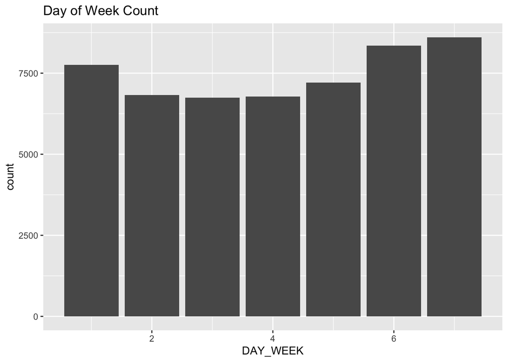

```r
tal1 <- accper %>%
  group_by(DAY_WEEK) %>%
  summarize(Weekdaycount=n())

tal2 <- accper %>%
  group_by(HOUR) %>%
  summarize(Hourcount=n()) %>%
  mutate(HOUR = factor(HOUR))

tal3 <- accper %>%
  group_by(SEX) %>%
  summarize(sexcount=n()) %>%
  mutate(SEX = factor(SEX))

ggplot(tal1, aes(x=DAY_WEEK, weight=Weekdaycount, fill=DAY_WEEK)) + geom_bar() + ggtitle('Day of Week Count')
```

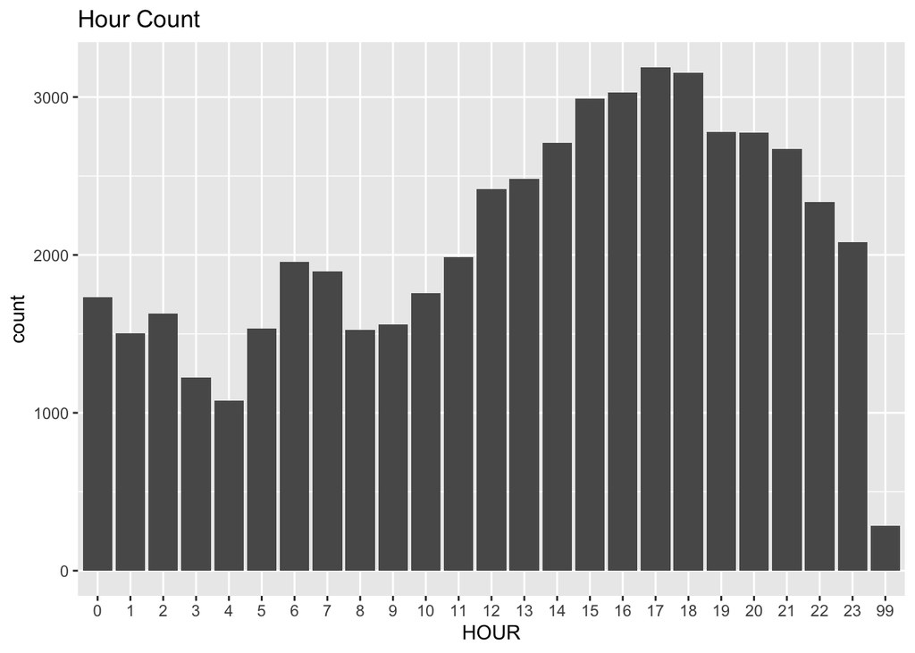

```r
ggplot(tal2, aes(x=HOUR, weight=Hourcount)) + geom_bar() + ggtitle('Hour Count')
```

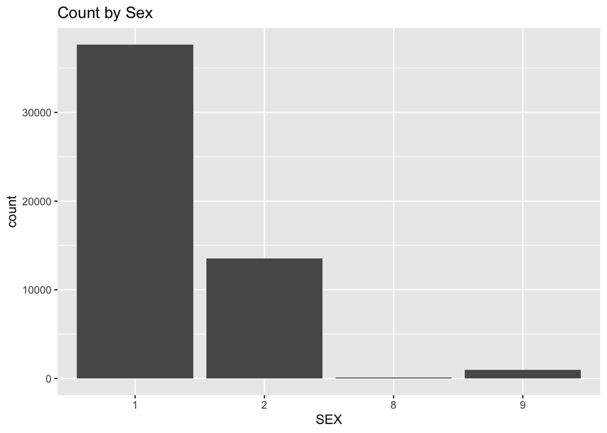

```r
ggplot(tal3, aes(x=SEX, weight=sexcount)) + geom_bar() + ggtitle('Count by Sex')
```

### Part Three: Connecting data and make maps

7. Now plot a choropleth map of accidents on a county level

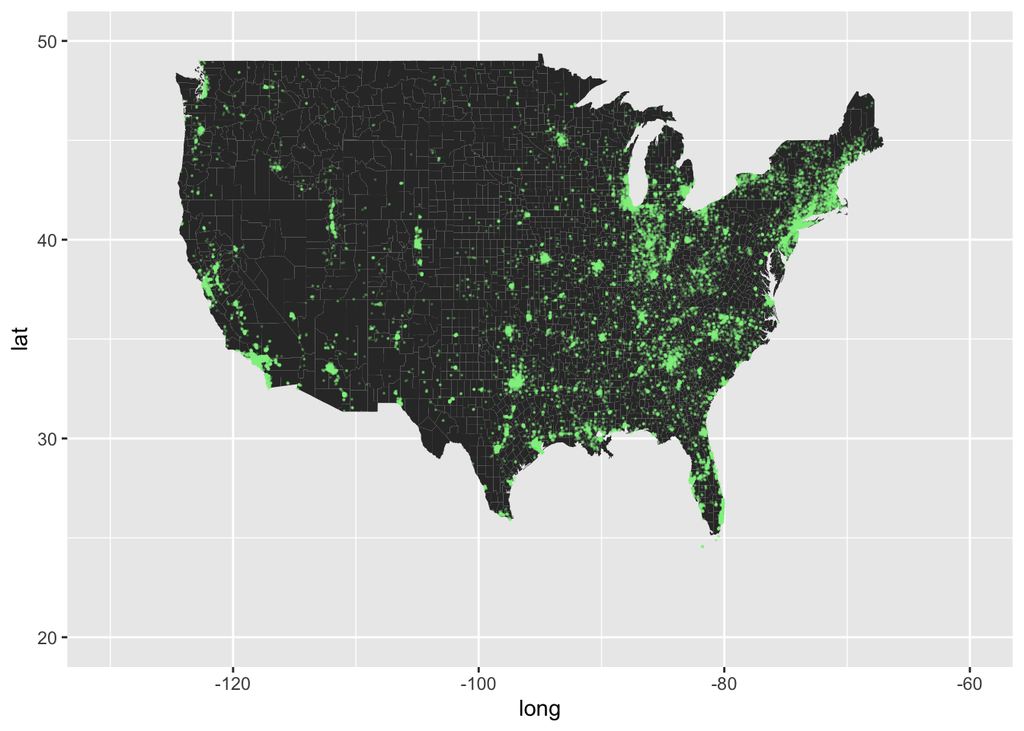

```r
GLCUS <- readxl::read_xlsx('/Users/TheemikezanilyMac/Documents/School/DS 202/ds202_lab5/GLCUS.xlsx')
counties <- map_data('county')

GLCUS2 <- GLCUS %>%
  mutate(`State Code` = as.integer(`State Code`),
         `County Code` = as.integer(`County Code`),
         `City Code` = as.integer(`City Code`)) %>%
  inner_join(accper,c(`County Code` = 'COUNTY', `State Code` = "STATE", `City Code` = 'CITY'))

ggplot(data=counties, aes(x=long, y=lat))+
  geom_polygon(aes(group=group))+
  geom_point(data = GLCUS2, aes(x=LONGITUD, y=LATITUDE), color='lightgreen', alpha=.2, size=.02)+
  xlim(c(-130,-60))+ylim(c(20,50))
```

9. Can you find seasonal trends in accident occurrences in different states? Is summer or winter more dangerous? Why?

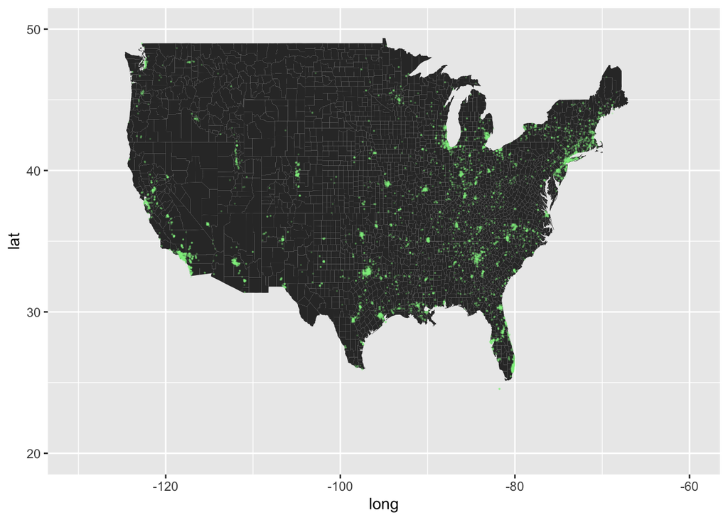

```r
ggplot(data=counties, aes(x=long, y=lat))+
  geom_polygon(aes(group=group))+
  geom_point(data = GLCUS2 %>% filter(MONTH %in% c(12,1,2)), aes(x=LONGITUD, y=LATITUDE), color='lightgreen', alpha=.2, size=.02)+
  xlim(c(-130,-60))+ylim(c(20,50))
```

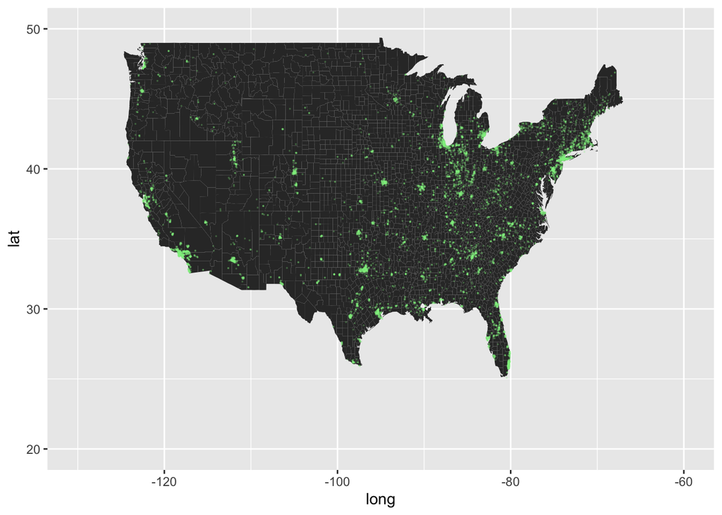

```r
ggplot(data=counties, aes(x=long, y=lat))+
  geom_polygon(aes(group=group))+
  geom_point(data = GLCUS2 %>% filter(MONTH %in% c(6,7,8)), aes(x=LONGITUD, y=LATITUDE), color='lightgreen', alpha=.2, size=.02)+
  xlim(c(-130,-60))+ylim(c(20,50))
```